# PM566 Midterm Project

Author

Jordan Walton

## Introduction

This project investigates how average team points and assists have changed in the NBA from 2010 to 2024, and which teams rank among the top five in each category over this period. By analyzing season-level team totals, I aim to uncover long-term offensive trends and highlight standout teams that exemplify scoring efficiency and ball movement. These metrics offer insight into evolving league strategies, including the rise of pace-and-space offenses and position-less play.

## Data Preparation

The dataset used for this analysis includes regular season totals for NBA teams from 2010 to 2024. It was provided as a CSV file containing variables such as “team”, “season_year”, “pts (total points)”, and “ast (total assists)”. The data was cleaned using the janitor package to standardize column names, and exploratory summaries were generated using dplyr and ggplot2.

Key preparation steps included renaming and cleaning column headers, grouping data by season_year to calculate league-wide averages, and aggregating by team to identify top performers in scoring and assists. No missing values were found in the key variables used for analysis.

```r
nba <- read_csv("regular_season_totals_2010_2024.csv") |>
  clean_names()
```

## Exploratory Analysis

- **pts**: total points scored by the team in a season
- **ast**: total assists recorded by the team in a season
- **season_year**: formatted as “YYYY–YY” to represent each NBA season

Distribution of key variables:

- Average team points ranged from ~96 in 2011–12 to over 114 in 2023–24
- Average team assists increased from ~21 in 2010–11 to nearly 27 in 2023–24

These distributions suggest a steady upward trend in offensive output and play-making across the league.

```r
# Group by season and calculate averages across teams
nba_summary <- nba |>
  group_by(season_year) |>
  summarize(
    avg_pts = mean(pts, na.rm = TRUE),
    avg_ast = mean(ast, na.rm = TRUE),
    .groups = "drop"
  )
```

```r
nba_summary <- nba_summary |>
  mutate(season_numeric = as.numeric(str_sub(season_year, 1, 4)))
```

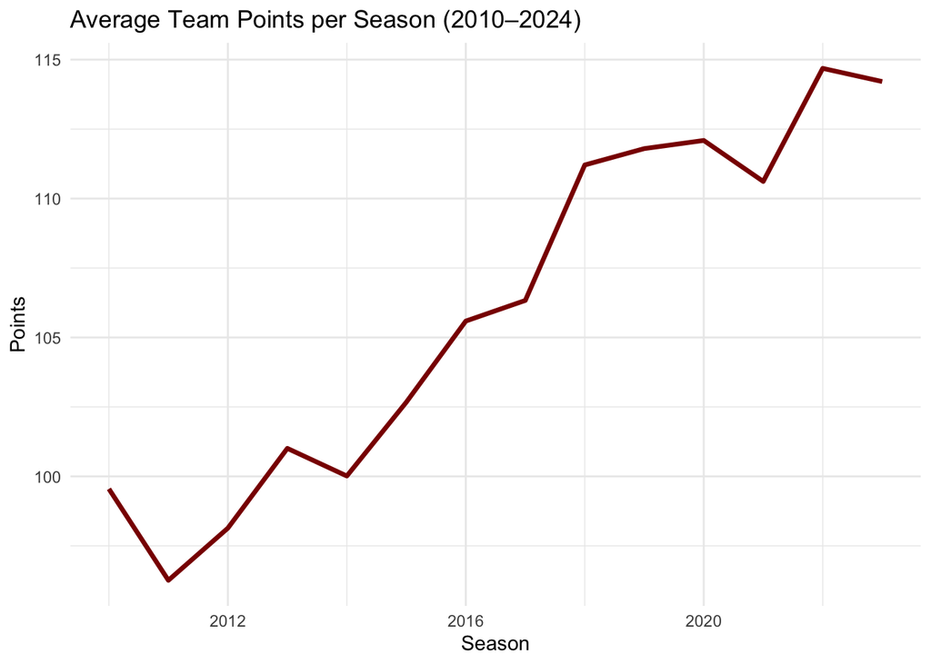

```r
ggplot(nba_summary, aes(x = season_numeric, y = avg_pts)) +
  geom_line(color = "darkred", size = 1.2) +
  labs(title = "Average Team Points per Season (2010–2024)",
       x = "Season", y = "Points") +
  theme_minimal()
```

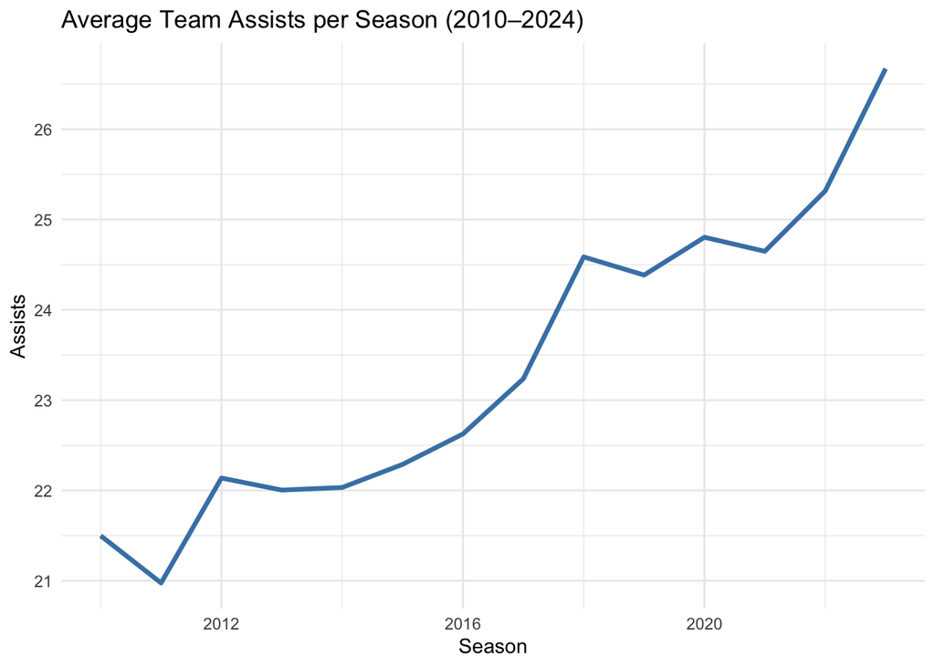

```r
ggplot(nba_summary, aes(x = season_numeric, y = avg_ast)) +
  geom_line(color = "steelblue", size = 1.2) +
  labs(title = "Average Team Assists per Season (2010–2024)",
       x = "Season", y = "Assists") +
  theme_minimal()
```

```r
top_pts_teams <- nba |>
  group_by(team_name) |>
  summarize(
    avg_pts = mean(pts, na.rm = TRUE)
  ) |>
  arrange(desc(avg_pts)) |>
  slice_head(n = 5)

kable(top_pts_teams, caption = "Top 5 Teams by Average Points (2010–2024)")
```

Top 5 Teams by Average Points (2010–2024)

| team_name | avg_pts |
| --- | --- |
| LA Clippers | 111.6017 |
| Golden State Warriors | 110.6606 |
| Houston Rockets | 109.4559 |
| New Orleans Pelicans | 109.1814 |
| Denver Nuggets | 109.1114 |

```r
top_ast_teams <- nba |>
  group_by(team_name) |>
  summarize(
    avg_ast = mean(ast, na.rm = TRUE)
  ) |>
  arrange(desc(avg_ast)) |>
  slice_head(n = 5)

kable(top_ast_teams, caption = "Top 5 Teams by Average Assists (2010–2024)")
```

Top 5 Teams by Average Assists (2010–2024)

| team_name | avg_ast |
| --- | --- |
| Golden State Warriors | 26.90136 |
| Denver Nuggets | 25.34411 |
| San Antonio Spurs | 25.03240 |
| New Orleans Pelicans | 24.75283 |
| Atlanta Hawks | 24.50949 |

## Preliminary Results

These trends reflect broader strategic shifts in the NBA, including increased pace, three-point shooting, and emphasis on ball movement.

Additionally, the top 5 teams by average points and average assists consistently demonstrated offensive excellence, either through high scoring or strong ball distribution. The Golden State Warriors notably appear in both lists, showing their dominance in both scoring and play-making.

## Conclusion

From 2010 to 2024, NBA teams have shown a clear upward trend in both scoring and assists, reflecting the league’s evolution toward faster, more collaborative offensive systems. The top-performing teams in each category highlight the strategic diversity across franchises, with some excelling in raw scoring and others in ball movement. These findings support the narrative that modern NBA offenses prioritize efficiency, spacing, and teamwork; thus showing a shift that continues to shape the game’s future.